# Subgroup Identification Analysis

Applications to consistency analyses in MRCTs

Author

Larry Leon

```r
# Set options
knitr::opts_chunk$set(
  echo = TRUE,
  warning = FALSE,
  message = FALSE,
  fig.align = 'center',
  fig.retina = 2
)
rm(list=ls())
library(tinytex)
library(ggplot2)
library(table1)

library(gt)

# test these packages
# just for testing any conflicts
# library(tidyverse)
# library(plyr)
# library(dplyr)
# library(glmnet)

library(survival)
library(data.table)
library(randomForest)
library(grf)
library(policytree)
library(DiagrammeR)

library(grid)
library(forestploter)
library(randomizr)

# library(devtools)
# install_github("larry-leon/weightedsurv", force = TRUE)

#install.packages("weightedsurv")


# install_github("larry-leon/forestsearch", force = TRUE)


library(forestsearch)
library(weightedsurv)

#help(forestsearch)

#help(generate_aft_dgm_flex)

# Set theme for plots
theme_set(theme_minimal(base_size = 12))
```

# 1 Summary

We evaluate the potential for utilizing subgroup analyses for enhancing regional consistency analyses in oncology multi-regional clinical trials (MRCTs). We consider a setting where asia pacific (AP) countries consist of approximately $15-20\%$ of a global trial and the criteria for consistency is a positive point estimate (Cox model hazard-ratio $< 1.0$) while the global trial meets statistical significance.

Suppose the following –

**ITT meets statistical significance but the AP regional analysis appears problematic (hazard-ratio estimate $\approx 1.0$)**

Can a subgroup with enhanced benefit be identified in the non-AP population which then translates to the AP population?

That is, suppose there exists a subgroup ${\cal G}$ such that the treatment affect is more pronounced and (standard) Cox model analyses based on the ${\cal G}$ subgroup of AP (AP$({\cal G})$, say) enables meeting consistency.

We assume Cox model analyses are the primary analysis where only the treatment arm is included as a covariate (with or without stratification by randomization factors).

While there are a plethora of subgroup identification approaches available we consider the *forestSearch* approach, León et al. (2024), which was developed for identifying strong subgroup treatment effects (i.e., strong HTEs).

We consider three objectives: (A) Identify a subgroup with the largest detrimental effect (*harm*, say) defined in terms of the largest hazard-ratio estimate exceeding a clinical threshold in favor of control (e.g., $\hat\beta \geq \log(0.90)$); (B) Identify the *smallest* subgroup with a hazard-ratio estimate indicative of *harm* (e.g., $\hat\beta \geq \log(0.90)$); and (C) Identify the *largest* subgroup with strong benefit (e.g., $\hat\beta \leq \log(0.60)$). These objectives are related with the overarching goal of identifying a subgroup with enhanced benefit; In (A) and (B) we identify a subgroup indicative of *harm*, $\hat{\cal H}$ say, in which case the complementary subgroup (${\hat{\cal H}}^{c}:= {\hat{\cal G}}$) may be generally beneficial. Whereas in (C) we are more directly *targeting* a strong (clinically compelling) beneficial subgroup effect.

Throughout this note R code is provided and illustrated based on real trial data (subject-level baseline characteristics are fixed at their observed quantities). Our hope is that these notes can serve as a framework for future trial planning as well as for simulating from study data to understand the operating characteristics for teams and external discussions.

A diagram illustrating the general flow follows.

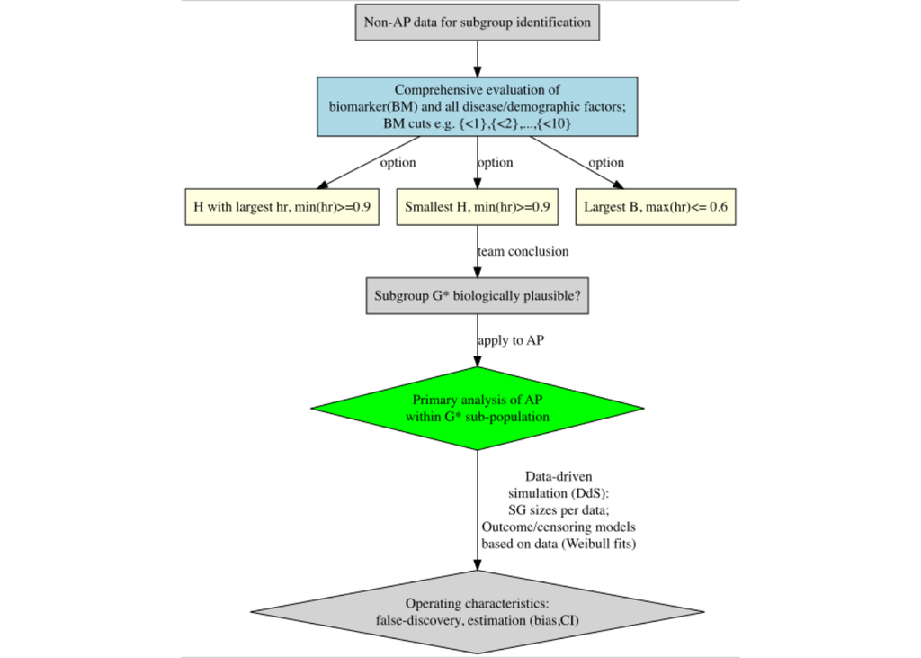

Subgroup identification analysis based on non-AP data to identify subgroups of marked benefit in AP. Operating characteristics evaluates whole process starting from analysis option

```r
library(png)
library(grid)
img <- readPNG('MRCT-Flow.png')
grid.raster(img)
```

# 2 Weibull AFT/Cox model with biomarker effects

## 2.1 Brief Review

For the Weibull distribution with shape parameter $\nu$ and scale parameter $\theta$ the density, cdf, survival, hazard and cumulative hazard functions are:
$$\begin{eqnarray*}
f(t) &=& \nu \theta^{-\nu}t^{\nu-1}\exp(-(t/\theta)^{\nu}), \cr F(t)
&=& \int_{0}^{t}\nu \theta^{-\nu}s^{\nu-1}\exp(-(s/\theta)^{\nu})ds
\cr &=& \int_{0}^{(t/\theta)^{\nu}}e^{-w}dw \cr & &
(w=(s/\theta)^{\nu},dw=\nu s^{\nu-1}\theta^{-\nu}ds) \cr
&=&1-\exp(-(t/\theta)^{\nu}), \cr S(t) &=& \exp(-(t/\theta)^{\nu}),
\cr \lambda(t)&=&\nu \theta^{-\nu}t^{\nu-1}, \cr \Lambda(t) &=&
-\log(S(t))=(t/\theta)^{\nu}.
\end{eqnarray*}$$
Note that here we define the density to correspond with R’s definition. For shape parameter $\nu \in (0,1)$ the hazard is strictly decreasing in $t \geq 0$, whereas for $\nu >1$ the hazard is strictly increasing in $t \geq 0$.

*Note*: $\Lambda(T) \sim E(1)$

The cumulative hazard function $\Lambda(\cdot)$ evaluated at $T$, $\Lambda(T)$, as a random variable has cdf
$$\eqalign{ \Pr(\Lambda(T) \leq t) &=\Pr(-\log(1-F(T)) \leq t) =\Pr(1-F(T) \geq e^{-t}) \cr
&=\Pr(T \leq F^{-1}(1-e^{-t})) =F(F^{-1}(1-e^{-t})) = 1-e^{-t}, \cr}$$
which is the CDF of the exponential distribution, $E(1)$ (say).

In the following we use

$$\begin{equation}
\tag{1}
\Lambda(T) \sim E(1)
\end{equation}$$
to represent the Weibull regression model as an AFT model which is also a Cox model.

Now, $\Lambda(T)=(T/\theta)^{\nu}$ and write $Q=-\log(S(T))=\Lambda(T)=(T/\theta)^{\nu}$, where from (1), $Q \sim E(1)$. That is $\log(Q)=\nu(\log(T)-\log(\theta))$ can be expressed as

$$\begin{equation}
\tag{2}
\log(T)=\log(\theta)+ \tau \log(Q) := \log(\theta) + \tau \epsilon,
\end{equation}$$
where $\tau=1/\nu$ and it is easy to show that $\epsilon=\log(Q)$ has the ``extreme value’’ distribution with density $f_{\epsilon}(x)=\exp(x-e^{x})$ for $x \in {\cal R}$. Here the range of $\log(T) \in {\cal R}$ is un-restricted. The *survReg* routine uses the parameterization $(2)$ and therefore estimates $\log(\theta)$ and $\tau=1/\nu$.

To incorporate covariates $L$ (say) we specify
$$\lambda(t;L)=\big(\nu \theta^{-\nu}t^{\nu-1} \big) \exp(L'\beta)
:= \lambda_{0}(t)\exp(L'\beta),$$
where $\lambda_{0}(t)$ is the hazard, say, for $T_{0} \sim \hbox{Weibull}(\nu,\theta)$. This is a special case of the proportional hazards model. The chf (conditional chf with covariate vector $L$) is $\Lambda(t;Z)=(t/\theta)^{\nu}\exp(L'\beta)$ so that analogous to above this leads to the representation

$$\begin{equation}
\tag{3}
\log(T) =\log(\theta)+\tau[-L'\beta+\epsilon] =\log(\theta)+L'\gamma + \tau \epsilon,
\end{equation}$$
where $\gamma=-\tau\beta$, with $\tau$ and $\epsilon$ defined in (2). R *survReg* uses this AFT parameterization so that the estimated components of $\gamma$, $\gamma_{p}$ say, are that of $-\tau\beta_{p}$ for $p=1,\ldots,m$ ($m$ is dimension of $\beta$).

When fitting the AFT model (3) via suvreg we therefore transform parameters $\hat\gamma$ to the Weibull hazard-ratio parameterization (2) via

$$\begin{equation}
\tag{4}
\hat\beta = -\hat\gamma / \hat{\tau}.
\end{equation}$$

As an illustration we compare the *survReg* model fits for the case-study dataset. The following table below compares the Weibull *survReg* model fits with covariates Treat and Ecog1 (Ecog = 1 vs 0) where components of $\hat\gamma$ from model (3) are calculated according to *survReg* and $\hat\beta$ are formed via (4). In the table below Weibull estimates of $\hat\beta$ are compared to Cox model versions.

# 3 Case-study

For illustration we use a synthetic case-study dataset that is based on a clinical trial with characteristics `perturbed` and masked.

The case-study dataset will be the basis for simulating subgroup effects generated by either binary factors, continuous covariates (e.g., biomarkers), or a combination.

This will serve as a framework for simulating from actual study data to evaluate operating characteristics of post-hoc analyses that may be conducted to understand `subgroup type` questions.

The objectives here are to evaluate the potential for utilizing subgroup identification methods to identify subgroup with `enhanced benefit` to inform regional consistency objectives of MRCTs as described in the introduction.

```r
# case-study example
# Draw sample from synthetic dataset (n=2,000)
dfsynth <- read.table("../data/dfsynthetic.csv", header=TRUE, sep=",")
df.case <- dfsynth
# Create "Asia Pacific (AP)" region flag variable
df.case$AP <- df.case$region_asia
```

## 3.1 Kaplan-Meier curves of synthetic dataset

Note that the outcomes are representative of the trial data

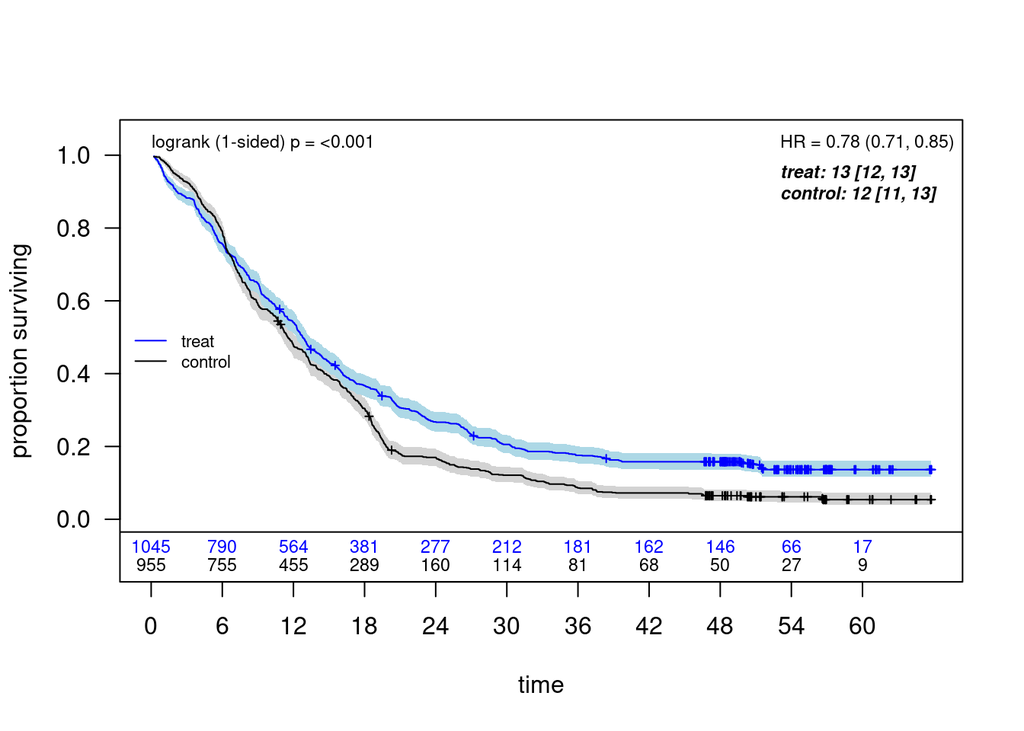

```r
# Restrict to 1st 500
#df.case0 <- subset(df.case, pid <= 500)

dfcount <- df_counting(
  df = df.case,
  by.risk = 6,
  tte.name = "tte",
  event.name = "event",
  treat.name = "treat"
)
plot_weighted_km(dfcount, conf.int = TRUE, show.logrank = TRUE, ymax = 1.05, xmed.fraction = 0.775, ymed.offset = 0.125)
```

```r
df.case$bm5 <- ifelse(df.case$bm >= 5, 1,0)

create_summary_table(data = df.case, treat_var="treat",
                     table_title = "N=500 Characteristics by Treatment Arm",
                                      vars_continuous=c("age","bm","entrytime"),
                                      vars_categorical=c("male","histology","prior_treat","AP","ecog","strat","bm5"),
                                      font_size = 12)
```

| Characteristic |  | Control (n=955) | Treatment (n=1045) | P-value<sup>1</sup> | SMD<sup>2</sup> |
| --- | --- | --- | --- | --- | --- |
| age | Mean (SD) | 60.5 (12.7) | 60.7 (12.0) | 0.603 | 0.02 |
| bm | Mean (SD) | 7.0 (6.5) | 8.6 (7.3) | <0.001 | 0.23 |
| entrytime | Mean (SD) | 11.3 (5.0) | 11.7 (4.8) | 0.099 | 0.07 |
| male |  |  |  | 0.033 | 0.05 |
|  | 0 | 282 (29.5%) | 263 (25.2%) |  |  |
|  | 1 | 673 (70.5%) | 782 (74.8%) |  |  |
| histology |  |  |  | <0.001 | 0.08 |
|  | 0 | 691 (72.4%) | 681 (65.2%) |  |  |
|  | 1 | 264 (27.6%) | 364 (34.8%) |  |  |
| prior_treat |  |  |  | 0.823 | 0.00 |
|  | none | 262 (27.4%) | 281 (26.9%) |  |  |
|  | surgery | 693 (72.6%) | 764 (73.1%) |  |  |
| AP |  |  |  | 0.786 | 0.01 |
|  | 0 | 717 (75.1%) | 778 (74.4%) |  |  |
|  | 1 | 238 (24.9%) | 267 (25.6%) |  |  |
| ecog |  |  |  | 0.524 | 0.01 |
|  | 0 | 436 (45.7%) | 493 (47.2%) |  |  |
|  | 1 | 519 (54.3%) | 552 (52.8%) |  |  |
| strat |  |  |  | 0.897 | 0.00 |
|  | 0 | 615 (64.4%) | 669 (64.0%) |  |  |
|  | 1 | 340 (35.6%) | 376 (36.0%) |  |  |
| bm5 |  |  |  | <0.001 | 0.11 |
|  | 0 | 414 (43.4%) | 338 (32.3%) |  |  |
|  | 1 | 541 (56.6%) | 707 (67.7%) |  |  |

<sup>1</sup> P-values: t-test for continuous, chi-square/Fisher's exact for categorical/binary variables  
<sup>2</sup> SMD = Standardized mean difference (Cohen's d for continuous, Cramer's V for categorical)

Illustration of correspondence between Weibull model and Cox

```r
library(dplyr)
# Comparing Weibull vs Cox with case-study
# This is just for illustration to show conversion of Weibull parameters from
# AFT regression to Weibull hazard
fit.weib_ex <- survreg(Surv(tte,pmax(event,1)) ~ treat + ecog, dist='weibull', data=df.case)
tauhat <- fit.weib_ex$scale
# convert (treat,ecog1) regression parms to Weibull hazard-ratio
bhat.weib <- -(1)*coef(fit.weib_ex)[c(2,3)]/tauhat
# Compare to Cox
fit.cox_ex <- coxph(Surv(tte,pmax(event,1)) ~ treat + ecog, data=df.case)
res <- cbind(bhat.weib,coef(fit.cox_ex))
res <- as.data.frame(res)
colnames(res)<-c("Weibull","Cox")
res |> gt() |>
fmt_number(columns=1:2,decimals=6) |>
tab_options(
    table.font.size = px(12)
  ) |>
tab_header(title="Comparing Weibull to Cox hazard ratio estimates",
subtitle="Case-study dataset with artificial outcomes")
```

Comparing Weibull to Cox hazard ratio estimates

Case-study dataset with artificial outcomes

| Weibull | Cox |
| --- | --- |
| −0.258118 | −0.221810 |
| 0.332700 | 0.337246 |

### 3.1.1 Overview

The `generate_aft_dgm_flex()` function creates a flexible data generating mechanism (DGM) for survival data that can incorporate complex, non-linear covariate effects through spline specifications. This is particularly useful for simulating realistic clinical trial scenarios where biomarker effects vary across their range.

### 3.1.2 Example: Creating a Spline-Based DGM

In this example, we create a DGM where the effect of a biomarker (`bm`) varies non-linearly, exhibiting different hazard ratios across three segments of the biomarker distribution.

```r
dgm_spline <- generate_aft_dgm_flex(
  data = df.case,
  # Main effects: continuous and factor variables
  # NOTE that ALL variables in the outcome model will have a "z_" prefix attached
  continuous_vars = c("age", "bm"),
  factor_vars = c("male", "histology", "prior_treat", "AP"),
  # Force specific coefficient for AP variable
  set_beta_spec = list(
    set_var = c("z_AP"),
    beta_var = -log(5)  # HR = 0.2 (strong protective effect)
    ),
  # Censoring mechanism covariates
  # NOTE that ALL variables in the censoring model will have a "zcens_" prefix attached
  # See notes below on how the censoring model is selected
  continuous_vars_cens = c("age"),
  factor_vars_cens = c("prior_treat"),
  cens_type = "weibull",
  # Outcome specification
  outcome_var = "tte",
  event_var = "event",
  treatment_var = "treat",
  # No additional subgroup factors
  subgroup_vars = NULL,
  subgroup_cuts = NULL,
  k_inter = 0.0,
  # indicate that subgroup effects are incorporated
  model = "alt",
  # Spline specification for non-linear biomarker effect
  spline_spec = list(
    var = "z_bm",                    # Variable with non-linear effect
    knot = 5,                        # Spline knot position
    zeta = 10,                       # Transition smoothness parameter
    log_hrs = log(c(2, 1.25, 0.5))  # Hazard ratios for the three segments
  ),
  verbose = TRUE,
  standardize = FALSE #default
)
```

```
=== Spline Constraint Applied ===
Target log(HR) at z_bm = 0: 0.693
Target log(HR) at z_bm = knot ( 5 ): 0.223
Target log(HR) at z_bm = zeta ( 10 ): -0.693
k_treat multiplier: 1

=== Model Parameters (AFT with Spline, log(T)) ===
Intercept (mu): 3.339
Scale (tau): 0.93
Spline variable: z_bm
  Knot: 5
  Zeta: 10
Treatment effect at z_bm = 0: -0.644
Treatment slope before knot: 0.087
Treatment slope change after knot: 0.083

Overall subgroup in super-population (all conditions met):
  Proportion: 0

=== Hazard Ratios (super popln) ===
Overall HR: 0.668
Causal AHR: 0.657
```

```
 ======================================================================
 CENSORING MODEL SELECTION:
 MULTIPLE SURVIVAL REGRESSION MODEL COMPARISONS
======================================================================

CONVERGENCE SUMMARY ( 4 / 4  converged):
--------------------------------------------------

Weibull (weibull):
  Status:  ✓ Converged
  Iterations:  30
  Log-likelihood:  -116753.1
  Scale parameter:  0.1056

LogNormal (lognormal):
  Status:  ✓ Converged
  Iterations:  17
  Log-likelihood:  -884.889
  Scale parameter:  0.2565

Weibull0 (weibull):
  Status:  ✓ Converged
  Iterations:  13
  Log-likelihood:  -769.085
  Scale parameter:  0.1192

LogNormal0 (lognormal):
  Status:  ✓ Converged
  Iterations:  7
  Log-likelihood:  -888.633
  Scale parameter:  0.2599

MODEL COMPARISON TABLE:
--------------------------------------------------
      Model       AIC delta_AIC AIC_weight       BIC delta_BIC
   Weibull0   1542.17      0.00          1   1553.37      0.00
  LogNormal   1779.78    237.61          0   1807.78    254.41
 LogNormal0   1781.27    239.10          0   1792.47    239.10
    Weibull 233516.14 231973.97          0 233544.14 231990.77

MODEL RANKINGS:
--------------------------------------------------
By AIC:  Weibull0 > LogNormal > LogNormal0 > Weibull
By BIC:  Weibull0 > LogNormal0 > LogNormal > Weibull

EVIDENCE ASSESSMENT:
--------------------------------------------------
  Strength:  Very strong evidence
  Details:  Top model has 100% of AIC weight

FINAL RECOMMENDATION:
--------------------------------------------------
  Clear winner: Weibull0 (best by both AIC and BIC)
  Evidence: Very strong evidence - Top model has 100% of AIC weight
======================================================================
```

### 3.1.3 Notes

- The `z_` prefix in variable names (e.g., `z_bm`, `z_AP`) indicates the original variables that are true factors in the outcome model when standardize=false (if true then the variables are standardized prior to estimation)
- Setting `k_inter = 0.0` turns off any treatment-subgroup interaction effects unless the spline model is implemented
- The `verbose = TRUE` option provides detailed output during DGM creation
- The `model = "alt"` specifies whether the true outcome model has heterogeneous treatment effects (HTEs)

For the **censoring distribution** with `cens_type ="weibull"`, `continuous_vars_cens = c("age")`, and `factor_vars_cens = c("prior_treat")` four censoring models will be estimated using weibull and log-normal distributions including treatment with the specified variables as well as no covariates. That is, if a weibull model without covariate adjustment is found to provide a better fit (per AIC/BIC) then this will be selected. NOTE that the censoring distribution is completely independent of the outcome model and so this aspect does not depend on how the survival times are generated.

#### 3.1.3.1 Examine beta = log(hr) parameters

Verify that the effect for “z_AP” is set to the specified value (Notice the “z_” prefixes)

Note that treatment effects with interactions (e.g., spline and/or subgroups) are interpreted below.

```r
library(dplyr)
b0_coefs <- dgm_spline$model_params$b0

coef_df <- data.frame(
  Coefficient = names(b0_coefs),
  Value = as.numeric(b0_coefs),
  HR = exp(as.numeric(b0_coefs))
) |>
  mutate(
    Type = case_when(
      grepl("^treat", Coefficient) ~ "Treatment Effects",
      grepl("^z_bm", Coefficient) ~ "Biomarker (Spline)",
      grepl("^z_", Coefficient) ~ "Baseline Covariates",
      TRUE ~ "Other"
    )
  )

coef_table_grouped <- coef_df |>
  arrange(Type, Coefficient) |>
  gt(groupname_col = "Type") |>
  fmt_number(
    columns = c(Value, HR),
    decimals = 4
  ) |>
  tab_header(
    title = "AFT Model Coefficients by Type",
    subtitle = "Weibull Parameterization (b0) with Hazard Ratios"
  ) |>
  cols_label(
    Coefficient = "Variable",
    Value = "b0 Coefficient",
    HR = "Hazard Ratio"
  ) |>
  tab_style(
    style = cell_text(weight = "bold"),
    locations = cells_column_labels()
  ) |>
  tab_style(
    style = cell_text(style = "italic"),
    locations = cells_row_groups()
  ) |>
  tab_options(
    table.font.size = px(12)
  )



coef_table_grouped
```

AFT Model Coefficients by Type

Weibull Parameterization (b0) with Hazard Ratios

| Variable | b0 Coefficient | Hazard Ratio |
| --- | --- | --- |
| Baseline Covariates |  |  |
| z_AP | −1.6094 | 0.2000 |
| z_age | 0.0035 | 1.0035 |
| z_histology | −0.0682 | 0.9341 |
| z_male | −0.1602 | 0.8520 |
| z_prior_treat | 0.2885 | 1.3345 |
| Biomarker (Spline) |  |  |
| z_bm | 0.1416 | 1.1522 |
| z_bm_k | −0.1803 | 0.8351 |
| z_bm_k_treat | −0.0893 | 0.9146 |
| z_bm_treat | −0.0940 | 0.9103 |
| Treatment Effects |  |  |
| treat | 0.6931 | 2.0000 |

```r
# Confirm forced parameter value
#cat("AP region parmeter = -log(5)?", c(dgm_spline$model_params$b0["z_AP"],-log(5)),"\n")
```

### 3.1.4 Understanding the Spline Specification

The `spline_spec` parameter creates a **three-segment piecewise effect** for the biomarker:

- **Segment 1** (low biomarker values): HR = 2.0 (harmful effect)
- **Segment 2** (intermediate values): HR = 1.25 (modest harmful effect)
- **Segment 3** (high biomarker values): HR = 0.5 (protective effect)

See log(hazard-ratio) plot below.

View the censoring parameters:

In this case example the best fitting censoring model is a common censoring model (weibull with NO covariates).

If the selected model included covariates then these would show up with “zcens_” prefixes attached. If `cens_type="uniform"` then a uniform model is implemented.

```r
dgm_spline$model_params$censoring
```

```
$mu
(Intercept)
   4.015714

$tau
[1] 0.1192412

$gamma
named numeric(0)

$type
[1] "weibull"
```

### 3.1.5 What is Created

The `dgm_spline` object contains:

1. **Linear coefficients** for all specified covariates (age, male, histology, prior_treat, AP)
2. **Spline parameters** defining the non-linear effect of the biomarker
3. **Censoring distribution parameters** (Weibull/lognormal with specified covariates, or uniform)
4. **Model structure** ready for use with `simulate_from_dgm()`

**Causal log-hazard-ratio**

Recall, the log(hazard-ratio) for biomarker level $z$ `="z_bm"` is a linear function of $z$ with a change-point (in slope) at $z=k$ given by

$$\begin{eqnarray*}
\psi^{0}(z) &=& \beta^{0}_{1} + \beta^{0}_{3}z, \quad \hbox{for} \ z \leq k, \cr
&=& \beta^{0}_{1} + \beta^{0}_{3}z + \beta^{0}_{5}(z-k), \quad \hbox{for} \ z > k.
\end{eqnarray*}$$

Log hazard-ratio parameters $(\beta^{0}_{1},\beta^{0}_{3},\beta^{0}_{5})$ can be chosen to generate “treatment effect patterns” by specifying $\psi^{0}(z)$ values at $z=0$, $z=k$, and $z=\zeta$ for $\zeta > k$. For specified $\psi^{0}(0)$, $\psi^{0}(k)$, and $\psi^{0}(\zeta)$ we have

$$\begin{eqnarray}
\beta^{0}_{1} &=& \psi^{0}(0), \cr
\beta^{0}_{3} &=& {(\psi^{0}(k) - \beta^{0}_{1}) \over k}, \cr
\beta^{0}_{5} &=& {(\psi^{0}(\zeta) - \beta^{0}_{1} - \beta^{0}_{3}\zeta) \over (\zeta -k)}.
\end{eqnarray}$$

In the above table $\beta^{0}_{1}$ corresponds to `treat`, $\beta^{0}_{2}$ to `z_bm`, $\beta^{0}_{3}$ to `z_bm_treat`, $\beta^{0}_{4}$ to `z_bm_k`, and $\beta^{0}_{5}$ to `z_bm_k_treat`.

Note that defining $m(1,z)$ [$m(0,z)$)] as the conditional expected value of $\log(T)$ with treatment set to experimental [control] given biomarker level $Z=z$

$$\psi^{0}(z) = \{m(0,z)-m(1,z)\}/\tau$$
which corresponds to the difference in the (true) means of the potential outcomes under experimental and control conditions ($\log(T[0,z]$ versus $\log(T[1,z]$, say).

The **super-population** dataset `dgm_spline$df_super`:

Note that in `df_super`: `lin_pred_1` = $m(1,z)/\tau$, `lin_pred_0` = $m(0,z)/\tau$, and `loghr_po` = $\psi^{0}(z) = {m(0,z) - m(1,z)}/\tau$

```r
# Note that here flag_harm is not relevant because of the spline specification and definition of "harm" depends on degree
# In discussion below we describe how to specify thresholds of "harm" corresponding to biomarker effects
create_summary_table(data=dgm_spline$df_super, treat_var="treat",
                     table_title = "Super-population Characteristics by Treatment Arm",
                                      vars_continuous=c("z_age","z_bm","entrytime","lin_pred_1","lin_pred_0","loghr_po"),
                                      vars_categorical=c("z_male","z_histology","z_prior_treat","z_AP","ecog","strat","region_other","flag_harm"),
                                      font_size = 12)
```

Super-population Characteristics by Treatment Arm

| Characteristic |  | Control (n=2355) | Treatment (n=2645) | P-value<sup>1</sup> | SMD<sup>2</sup> |
| --- | --- | --- | --- | --- | --- |
| z_age | Mean (SD) | 60.5 (13.1) | 61.0 (11.7) | 0.182 | 0.04 |
| z_bm | Mean (SD) | 7.0 (6.4) | 8.7 (7.3) | <0.001 | 0.25 |
| entrytime | Mean (SD) | 11.4 (4.9) | 11.7 (4.7) | 0.022 | 0.07 |
| lin_pred_1 | Mean (SD) | 0.0 (1.3) | 0.3 (1.4) | <0.001 | 0.22 |
| lin_pred_0 | Mean (SD) | -0.2 (0.7) | -0.2 (0.7) | 0.131 | 0.04 |
| loghr_po | Mean (SD) | -0.3 (1.1) | -0.6 (1.2) | <0.001 | 0.24 |
| z_male |  |  |  | <0.001 | 0.05 |
|  | 0 | 681 (28.9%) | 642 (24.3%) |  |  |
|  | 1 | 1674 (71.1%) | 2003 (75.7%) |  |  |
| z_histology |  |  |  | <0.001 | 0.07 |
|  | 0 | 1715 (72.8%) | 1746 (66.0%) |  |  |
|  | 1 | 640 (27.2%) | 899 (34.0%) |  |  |
| z_prior_treat |  |  |  | 0.886 | 0.00 |
|  | 0 | 665 (28.2%) | 741 (28.0%) |  |  |
|  | 1 | 1690 (71.8%) | 1904 (72.0%) |  |  |
| z_AP |  |  |  | 0.267 | 0.02 |
|  | 0 | 1780 (75.6%) | 1962 (74.2%) |  |  |
|  | 1 | 575 (24.4%) | 683 (25.8%) |  |  |
| ecog |  |  |  | 0.340 | 0.01 |
|  | 0 | 1098 (46.6%) | 1270 (48.0%) |  |  |
|  | 1 | 1257 (53.4%) | 1375 (52.0%) |  |  |
| strat |  |  |  | 0.588 | 0.01 |
|  | 0 | 1481 (62.9%) | 1684 (63.7%) |  |  |
|  | 1 | 874 (37.1%) | 961 (36.3%) |  |  |
| region_other |  |  |  | <0.001 | 0.11 |
|  | A | 1390 (59.0%) | 1833 (69.3%) |  |  |
|  | B | 965 (41.0%) | 812 (30.7%) |  |  |
| flag_harm |  |  |  |  |  |
|  | 0 | 2355 (100.0%) | 2645 (100.0%) |  |  |

<sup>1</sup> P-values: t-test for continuous, chi-square/Fisher's exact for categorical/binary variables  
<sup>2</sup> SMD = Standardized mean difference (Cohen's d for continuous, Cramer's V for categorical)

### 3.1.6 Simulating Data from the DGM

Once created, the DGM can be used to generate synthetic datasets:

Here we generate n=500 retaining the treatment assigment of the case-study to mimic the randomization and utilize the actual entry times (if available).

```r
# Generate a dataset with n=500 subjects:
# Randomized 1:1 (rand_ratio=1);
# Retain the original treatment assignment in df.case (draw_treatment=FALSE)
# Note that draw_treatment=TRUE will draw randomized treatment assignments
# Use observed entry times per df.case if provided (entry_var = entrytime);
# Otherwise entry times are simulated as uniform(0, max_entry)
# Entry times are then incorporated in administrative censoring at the time
# of analysis (eg., analysis_time = 60);
# That is, subjects with entrytime > analysis_time are not available
# and follow-up is "60 - entrytime" for each subjects entrytime value
# The cens_adjust argument allows for increasing or decreasing the mean of
# the censoring distribution in order to reduce or increase the censoring rate
df_example <- simulate_from_dgm(
  dgm = dgm_spline,
  n = 500,
  rand_ratio = 1,
  draw_treatment = FALSE,
  entry_var = "entrytime",
  analysis_time = 60,
  cens_adjust = 0,
  seed = 12345
)

# Examine the simulated data structure
head(df_example)
```

```
      id         y treat event z_age z_bm z_male z_histology z_prior_treat z_AP
367    1  1.807991     0     1    59    2      1           1             1    0
453    2 14.811500     1     1    68    5      1           0             0    0
318    3 54.728171     1     0    66    5      1           0             0    0
901    4 10.320351     1     1    31    1      0           0             1    0
880.6  5  6.223409     0     1    78   20      1           1             0    0
367.1  6  1.807991     0     1    59    2      1           1             1    0
      entrytime strat ecog region_other region_asia pid bm5 zcens_age
367   16.343543     0    0            B           0 367   0        59
453    8.926491     1    0            B           0 453   1        68
318   11.335209     1    0            B           0 318   1        66
901   10.858361     1    1            B           0 901   0        31
880.6 15.595775     0    1            B           0 880   1        78
367.1 16.343543     0    0            B           0 367   0        59
      zcens_prior_treat flag_harm z_bm_treat z_bm_k z_bm_k_treat lin_pred_1
367                   1         0          0      0            0 -0.9786375
453                   0         0          5      0            0 -0.9356181
318                   0         0          5      0            0 -0.9291817
901                   1         0          1      0            0 -1.0565329
880.6                 0         0          0     15            0  2.1891150
367.1                 1         0          0      0            0 -0.9786375
      lin_pred_0 lin_pred_obs   theta_0    theta_1   loghr_po lin_pred_cens_0
367   -0.5090958   -0.5090958 0.5476992  1.0528449  0.5051457        4.015714
453   -0.7282023   -0.9356181 0.7834200  1.0065635  0.2231436        4.015714
318   -0.7217660   -0.9291817 0.7764956  0.9996391  0.2231436        4.015714
901   -0.4996160   -1.0565329 0.5375006  1.1366470  0.5991465        4.015714
880.6 -0.1585931   -0.1585931 0.1706188 -2.3551099 -2.5257286        4.015714
367.1 -0.5090958   -0.5090958 0.5476992  1.0528449  0.5051457        4.015714
      lin_pred_cens_1 treat_sim     y_sim event_sim    t_true   c_time
367          4.015714         0 35.059304         1 35.059304 43.65646
453          4.015714         1  1.005886         1  1.005886 51.07351
318          4.015714         1 18.353062         1 18.353062 48.66479
901          4.015714         1  2.414300         1  2.414300 49.14164
880.6        4.015714         0 28.758071         1 28.758071 44.40423
367.1        4.015714         0 24.571567         1 24.571567 43.65646
```

```r
# Note that y_sim, treat_sim, and event_sim are the outcomes, treatment, and events for the simulated data
# t_true are the uncensored outcomes, and c_time are the uncensored (not censored by outcomes) censoring times
# Of course in reality t_true and c_time are not observable
create_summary_table(data = df_example, treat_var="treat_sim",
                                      table_title = "Simulated data (n=500) from Spline Model",
                                      vars_continuous=c("y_sim","t_true","c_time","z_age","z_bm","entrytime","lin_pred_1","lin_pred_0","loghr_po"),
                                      vars_categorical=c("event_sim","z_male","z_histology","z_prior_treat","z_AP","ecog","strat","region_other","flag_harm"))
```

Simulated data (n=500) from Spline Model

| Characteristic |  | Control (n=247) | Treatment (n=253) | P-value<sup>1</sup> | SMD<sup>2</sup> |
| --- | --- | --- | --- | --- | --- |
| y_sim | Mean (SD) | 18.3 (15.9) | 25.4 (18.8) | <0.001 | 0.41 |
| t_true | Mean (SD) | 22.6 (27.2) | 86.0 (222.3) | <0.001 | 0.40 |
| c_time | Mean (SD) | 48.7 (4.8) | 48.9 (4.7) | 0.633 | 0.04 |
| z_age | Mean (SD) | 60.7 (13.9) | 61.1 (11.2) | 0.757 | 0.03 |
| z_bm | Mean (SD) | 6.6 (6.3) | 8.4 (7.3) | 0.004 | 0.26 |
| entrytime | Mean (SD) | 11.3 (4.8) | 11.1 (4.7) | 0.633 | 0.04 |
| lin_pred_1 | Mean (SD) | -0.1 (1.2) | 0.3 (1.3) | 0.002 | 0.28 |
| lin_pred_0 | Mean (SD) | -0.3 (0.6) | -0.2 (0.7) | 0.112 | 0.14 |
| loghr_po | Mean (SD) | -0.2 (1.0) | -0.5 (1.2) | 0.005 | 0.25 |
| event_sim |  |  |  | <0.001 | 0.22 |
|  | 0 | 34 (13.8%) | 83 (32.8%) |  |  |
|  | 1 | 213 (86.2%) | 170 (67.2%) |  |  |
| z_male |  |  |  | 0.006 | 0.12 |
|  | 0 | 84 (34.0%) | 57 (22.5%) |  |  |
|  | 1 | 163 (66.0%) | 196 (77.5%) |  |  |
| z_histology |  |  |  | 0.951 | 0.00 |
|  | 0 | 180 (72.9%) | 186 (73.5%) |  |  |
|  | 1 | 67 (27.1%) | 67 (26.5%) |  |  |
| z_prior_treat |  |  |  | 0.888 | 0.01 |
|  | 0 | 65 (26.3%) | 69 (27.3%) |  |  |
|  | 1 | 182 (73.7%) | 184 (72.7%) |  |  |
| z_AP |  |  |  | 0.230 | 0.05 |
|  | 0 | 193 (78.1%) | 185 (73.1%) |  |  |
|  | 1 | 54 (21.9%) | 68 (26.9%) |  |  |
| ecog |  |  |  | 0.955 | 0.00 |
|  | 0 | 109 (44.1%) | 110 (43.5%) |  |  |
|  | 1 | 138 (55.9%) | 143 (56.5%) |  |  |
| strat |  |  |  | 1.000 | 0.00 |
|  | 0 | 145 (58.7%) | 149 (58.9%) |  |  |
|  | 1 | 102 (41.3%) | 104 (41.1%) |  |  |
| region_other |  |  |  | <0.001 | 0.22 |
|  | A | 136 (55.1%) | 193 (76.3%) |  |  |
|  | B | 111 (44.9%) | 60 (23.7%) |  |  |
| flag_harm |  |  |  |  |  |
|  | 0 | 247 (100.0%) | 253 (100.0%) |  |  |

<sup>1</sup> P-values: t-test for continuous, chi-square/Fisher's exact for categorical/binary variables  
<sup>2</sup> SMD = Standardized mean difference (Cohen's d for continuous, Cramer's V for categorical)

### 3.1.7 Visualizing the Non-Linear Effect

The non-linear effect of the biomarker can be visualized by plotting the log hazard ratio across the range of biomarker values:

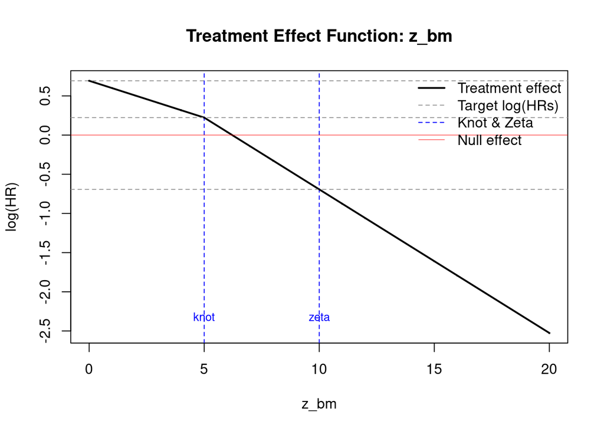

```r
# Plot the spline effect
plot_spline_treatment_effect(dgm_spline)
```

A *more detailed* look at the spline causal effects: AHR, and CDEs

We draw a large trial (n=5000) as a large sample approximation to summarize the underlying `population` effects.

```
=====================================
Cox AHR/CDE Analysis
=====================================
Sample size: 5000
Events: 3758
Treatment allocation: 2395 2605
Biomarker range: 0 20
CDE variables available: TRUE
-------------------------------------

Step 1: Fitting Cox spline model...

=== Z Variable Summary ===
Range: 0 20
Quantiles (75%, 80%, 90%): 11 15 20
Prediction grid: 21 points from 0 to 20

=== Primary Cox Model ===
Treatment log(HR): -0.395
Treatment HR: 0.674

=== Spline Model ===
Number of parameters: 7
Treatment main effect: 0.261

Step 2: Calculating AHR and CDE metrics...
Calculating Controlled Direct Effects (CDEs)...

Step 3: Calculating subgroup statistics...

Subgroup Summary:
      Subgroup    n n_pct events AHR_po   CDE
1 Questionable 1838  36.8   1598  1.740 1.731
2    Recommend 3162  63.2   2160  0.373 0.716
3      Overall 5000 100.0   3758  0.657 1.045

Optimal cutpoint (z_bm >= 5) defines 'Recommend' subgroup

Step 4: Creating visualizations...
```

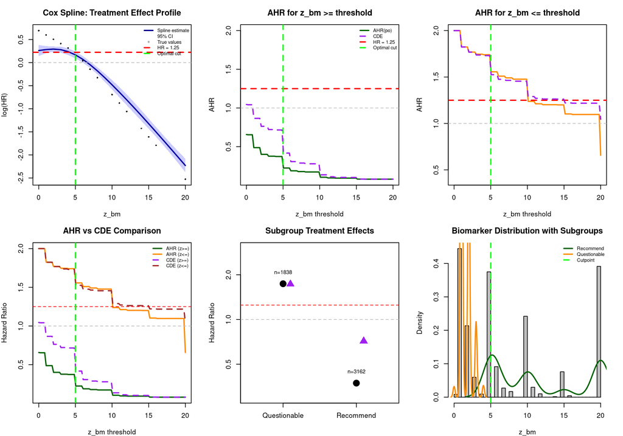

```
=====================================
Analysis Complete
=====================================
Optimal cutpoint: 5
Recommend subgroup size: 3162 ( 63.2 %)
AHR (Recommend): 0.373
CDE (Recommend): 0.716
=====================================
```

```r
# Large sample approximation

df_large <- simulate_from_dgm(
  dgm = dgm_spline,
  n = 5000,
  rand_ratio = 1,
  draw_treatment = FALSE,
  entry_var = "entrytime",
  analysis_time = 60,
  cens_adjust = 0,
  seed = 12345
)


# hr_threshold = 1.25 specifies finding the biomarker level such that the AHR (loghr_po) is above 1.25

results <- cox_ahr_cde_analysis(
   df = df_large,
   tte_name = "y_sim", event_name = "event_sim", treat_name = "treat_sim",
   z_name = "z_bm",
   hr_threshold = 1.25,
   plot_style = "grid"
 )
```

```r
 res <-results$subgroup_stats
 cut_hr <- results$optimal_cutpoint

res |>
  gt() |>
  tab_header(
    title = "Subgroup Statistics"
  ) |>
  tab_source_note(
    source_note = md(paste0("*HR threshold biomarker cutpoint: ",
                            round(cut_hr, 3), "*"))
  ) |>
  # Format first 3 columns with 0 decimals
  fmt_number(
    columns = 1:4,
    decimals = 0
  ) |>
  # Format remaining numeric columns with 3 decimals
  fmt_number(
    columns = -c(1:4),
    decimals = 3
  ) |>
  tab_style(
    style = cell_text(weight = "bold"),
    locations = cells_column_labels()
  ) |>
  tab_options(
    table.font.size = px(12)
  )
```

Subgroup Statistics

| Subgroup | n | n_pct | events | AHR_po | CDE |
| --- | --- | --- | --- | --- | --- |
| Questionable | 1,838 | 37 | 1,598 | 1.740 | 1.731 |
| Recommend | 3,162 | 63 | 2,160 | 0.373 | 0.716 |
| Overall | 5,000 | 100 | 3,758 | 0.657 | 1.045 |

*HR threshold biomarker cutpoint: 5*

Next, a simulated example (n=500) with forestsearch subgroup identification

- Here we simulated a study according to the biomarker effects described above
- Summarize the non-AP and AP populations (K-M plots)
- Apply subgroup identification procedures to the non-AP data and apply to AP

Returning to the simulated example data `df_example` (described above): (a) View K-M curves; (b) Estimate spline model to compare with true biomarker effects; and (c) Apply forestsearch to identify subgroups base on non-AP data and applied to AP.

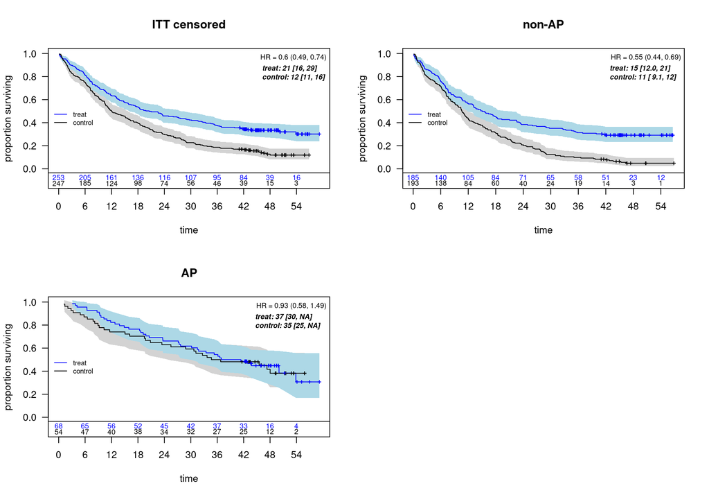

```r
# ITT
dfc <- df_counting(
  df = df_example,
  by.risk = 6,
  tte.name = "y_sim",
  event.name = "event_sim",
  treat.name = "treat_sim"
)
# No censoring
# Except by max_follow
df_example$t_true <- pmin(df_example$t_true, 100)
df_example$event_mod <- ifelse(df_example$t_true <= 100,1,0)
dfideal <- df_counting(
  df = df_example,
  by.risk = 6,
  tte.name = "t_true",
  event.name = "event_mod",
  treat.name = "treat_sim"
)
df_nonAP <- subset(df_example, z_AP == 0)
df_AP <- subset(df_example, z_AP == 1)
# non-AP
dfc0 <- df_counting(
  df = df_nonAP,
  by.risk = 6,
  tte.name = "y_sim",
  event.name = "event_sim",
  treat.name = "treat_sim"
)

# AP
dfc1 <- df_counting(
  df = df_AP,
  by.risk = 6,
  tte.name = "y_sim",
  event.name = "event_sim",
  treat.name = "treat_sim"
)


par(mfrow=c(2,2))

plot_weighted_km(dfc, conf.int = TRUE, show.logrank = FALSE, ymax = 1, xmed.fraction = 0.75, ymed.offset = 0.15)
title("ITT censored")

plot_weighted_km(dfc0, conf.int = TRUE, show.logrank = FALSE, ymax = 1, xmed.fraction = 0.725, ymed.offset = 0.15)
title("non-AP")

plot_weighted_km(dfc1, conf.int = TRUE, show.logrank = FALSE, ymax = 1, xmed.fraction = 0.725, ymed.offset = 0.15)
title("AP")
```

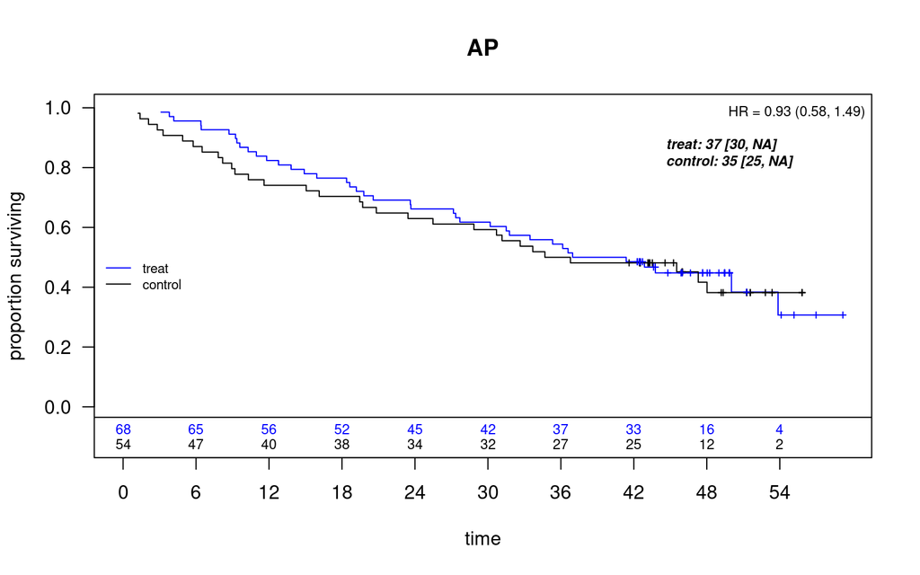

```r
plot_weighted_km(dfc1, conf.int = FALSE, show.logrank = FALSE, ymax = 1, xmed.fraction = 0.725, ymed.offset = 0.15)
title("AP")
```

Spline fit to observed data

```
=== Z Variable Summary ===
Range: 0 20
Quantiles (75%, 80%, 90%): 10 15 20
Prediction grid: 21 points from 0 to 20

=== Primary Cox Model ===
Treatment log(HR): -0.506
Treatment HR: 0.603

=== Spline Model ===
Number of parameters: 7
Treatment main effect: 0.08
```

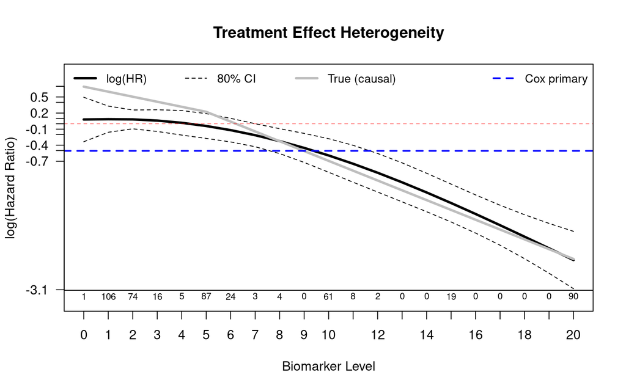

```r
result <- cox_cs_fit(
  df = df_example, tte_name = "y_sim", event_name ="event_sim", treat_name = "treat_sim",
  truebeta_name = "loghr_po",
  z_name = "z_bm", z_by = 1, z_window = 0.5,
  alpha = 0.20,
  plot_params = list(
    xlab = "Biomarker Level",
    main_title = "Treatment Effect Heterogeneity"
  )
)
```

# 4 Subgroup identification criteria: Options for targeting subgroup effects

## 4.1 Finding Non-AP subgroup with highest consistency rate (in favor of control)

Here we are seeking to identify subgroups where the hazard ratio estimate is at least $\log(0.90)$ which may indicate limited benefit. Further, subgroup candidates are ranked according to highest hazard ratio estimate and highest consistency rate.

```
GRF stage for cut selection with dmin,tau= 12 0.6
tau, maxdepth = 25.15602 2
   leaf.node control.mean control.size control.se depth
1          2         2.83       140.00       1.43     1
2          3        -3.90       238.00       0.99     1
21         5        -6.20        85.00       1.71     2
3          6         2.32       155.00       1.31     2
4          7        -5.18       108.00       1.38     2
GRF subgroup NOT found
NO GRF cuts meeting delta(RMST): dmin.grf= 12
# of continuous/categorical characteristics 2 5
Continuous characteristics: z_age z_bm
Categorical characteristics: z_male ecog z_histology z_prior_treat strat
## Prior to lasso: z_age z_bm
#### Lasso selection results
7 x 1 sparse Matrix of class "dgCMatrix"
                        s0
z_age          0.004737101
z_bm          -0.081215317
z_male         0.032432112
ecog           0.195631837
z_histology    .
z_prior_treat  0.305692103
strat         -0.140388689
Cox-LASSO selected: z_age z_bm z_male ecog z_prior_treat strat
Cox-LASSO not selected: z_histology
### End Lasso selection
## After lasso: z_age z_bm
Default cuts included from Lasso: z_age <= mean(z_age) z_age <= median(z_age) z_age <= qlow(z_age) z_age <= qhigh(z_age) z_bm <= mean(z_bm) z_bm <= median(z_bm) z_bm <= qlow(z_bm) z_bm <= qhigh(z_bm)
Categorical after Lasso: z_male ecog z_prior_treat strat

===== CONSOLIDATED CUT EVALUATION (IMPROVED) =====
Evaluating 15 cut expressions once and caching...
Cut evaluation summary:
  Total cuts:  15
  Valid cuts:  15
  Errors:  0
✓ All 15 factors validated as 0/1
===== END CONSOLIDATED CUT EVALUATION =====

```

[output cut: 17 more lines]

```
13          ecog    q13  0.0251
12        z_male    q12  0.0237
8    z_age <= 51     q8  0.0232
6  z_age <= 59.4     q6  0.0204
9    z_age <= 68     q9  0.0109
2      z_bm <= 0     q2  0.0000
Number of possible configurations (<= maxk): maxk = 1 , # combinations = 30
Events criteria: control >= 12 , treatment >= 12
Subgroup search completed in 0 minutes
Found 5 subgroup candidate(s)
# of candidate subgroups (meeting all criteria) = 5
# of unique initial candidates: 5
# Restricting to top stop_Kgroups = 30
# of candidates restricted to 'top K': 5
Using parallel processing: callr with 100 workers
```

```
Consistency met!
# of splits = 1000
**** Subgroup, % Consistency Met= {z_bm <= 1} 1
Consistency met!
# of splits = 1000
**** Subgroup, % Consistency Met= {z_bm <= 2} 1
Consistency met!
# of splits = 1000
**** Subgroup, % Consistency Met= {z_bm <= 5} 1
Consistency met!
# of splits = 1000
**** Subgroup, % Consistency Met= {z_bm <= 7.7} 1
Consistency met!
# of splits = 1000
**** Subgroup, % Consistency Met= {z_bm <= 11} 0.99
```

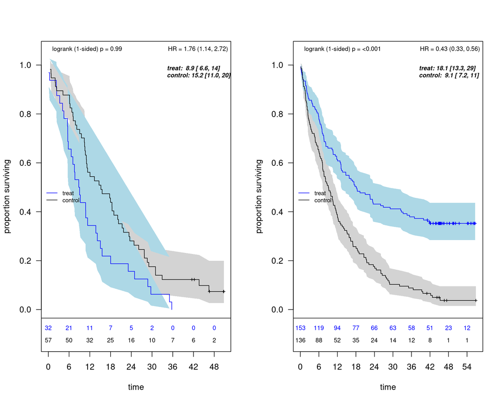

```
*** Subgroup found: {z_bm <= 1}
% consistency criteria met= 1
SG focus= minSG
Subgroup Consistency Minutes= 0.08988333
Subgroup found (FS) with sg_focus='minSG'
Selected subgroup: {z_bm <= 1}
Minutes forestsearch overall = 0.1
```

```
   user  system elapsed
 25.592   1.513   5.862
```

```r
confounders.name <- c("z_age","z_bm","z_male","ecog","z_histology","z_prior_treat","strat")

dfa <- as.data.frame(df_nonAP)

# Setup parallel processing
library(doFuture)
library(doRNG)

registerDoFuture()
registerDoRNG()

# Analysis dataset (estimation/training) is non-AP (df_nonAP)
# Testing dataset is AP (df_AP) --> predictions per non-AP analysis are applied to AP

system.time({fs <- forestsearch(dfa,  confounders.name=confounders.name,
                                outcome.name = "y_sim", treat.name = "treat_sim", event.name = "event_sim", id.name = "id",
                                potentialOutcome.name = "loghr_po",
                                df.test = as.data.frame(df_AP),
                                flag_harm.name = NULL,
                                hr.threshold = 0.9, hr.consistency = 0.80, pconsistency.threshold = 0.80,
                                sg_focus = "minSG", max_subgroups_search = 30,
                                showten_subgroups = TRUE, details=TRUE,
                                conf_force = c("z_age <= 65", "z_bm <= 0", "z_bm <= 1", "z_bm <= 2","z_bm <= 5"),
                                cut_type = "default", use_grf = TRUE, plot.grf = TRUE, use_lasso = TRUE,
                                maxk = 1, n.min = 60, d0.min = 12, d1.min = 12,
                                plot.sg = TRUE, by.risk = 6,
                                parallel_args = list(plan="callr", workers = 100, show_message = TRUE)
)
})
```

```r
plan("sequential")


# Results for estimation (training) data, which_df = "est" is default
res_tabs <- sg_tables(fs, ndecimals = 3, which_df = "est")

res_tabs$sg10_out
```

**Identified Subgroups**

Single-factor subgroups (maxk=1)

| Factor | N | Events | E<sub>1</sub> | HR | P<sub>cons</sub> |
| --- | --- | --- | --- | --- | --- |
| {z_bm <= 1} | 89 | 84 | 32 | 1.757 | 1.000 |
| {z_bm <= 2} | 140 | 133 | 59 | 1.547 | 1.000 |
| {z_bm <= 5} | 218 | 210 | 94 | 1.430 | 1.000 |
| {z_bm <= 7.7} | 234 | 226 | 101 | 1.367 | 1.000 |
| {z_bm <= 11} | 288 | 276 | 121 | 1.096 | 0.990 |

**Search Configuration:** Single-factor candidates (L) = 30; Maximum combinations evaluated = 30; Search depth (maxk) = 1  
**Search Results:** Candidate subgroups found = 5; Maximum HR estimate = 1.76  
**Note:** E<sub>1</sub> = events in treatment arm; P<sub>cons</sub> = consistency proportion

```r
res_tabs$tab_estimates
```

**Treatment Effect Estimates**

Training data estimates

| Subgroup | n | n1 | events | m1 | m0 | RMST | HR (95% CI) | AHR(po) |
| --- | --- | --- | --- | --- | --- | --- | --- | --- |
| ITT | 378 (100.0%) | 185 (48.9%) | 313 (82.8%) | 15.1 | 10.6 | 9.9 | 0.55 (0.44, 0.69) | 0.67 |
| Questionable | 89 (23.5%) | 32 (36.0%) | 84 (94.4%) | 8.9 | 15.2 | -5.2 | 1.76 (1.14, 2.72) | 1.82 |
| Recommend | 289 (76.5%) | 153 (52.9%) | 229 (79.2%) | 18.1 | 9.1 | 14 | 0.43 (0.33, 0.56) | 0.49 |

```r
# Results for testing dataset (AP)
res_tabs <- sg_tables(fs, ndecimals = 3, which_df = "testing", est_caption = "Testing (AP) dataset")
res_tabs$tab_estimates
```

**Treatment Effect Estimates**

Testing (AP) dataset

| Subgroup | n | n1 | events | m1 | m0 | RMST | HR (95% CI) | AHR(po) |
| --- | --- | --- | --- | --- | --- | --- | --- | --- |
| ITT | 122 (100.0%) | 68 (55.7%) | 70 (57.4%) | 39.2 | 35.7 | 1.9 | 0.93 (0.58, 1.49) | 0.78 |
| Questionable | 18 (14.8%) | 15 (83.3%) | 9 (50.0%) | 50 | NA | -9.1 | 1.97 (0.28, 13.96) | 1.82 |
| Recommend | 104 (85.2%) | 53 (51.0%) | 61 (58.7%) | 37 | 33.7 | 1.9 | 0.92 (0.56, 1.51) | 0.67 |

Next, generate under `null` where treatment is uniform. Here we set a constant biomarker effect such that hr = 0.7

```r
dgm_spline_null <- generate_aft_dgm_flex(
  data = df.case,
  continuous_vars = c("age", "bm"),
  factor_vars = c("male", "histology", "prior_treat","AP"),
  set_beta_spec = list(set_var = c("z_AP"), beta_var = -log(5)),
  continuous_vars_cens = c("age"),
  factor_vars_cens = c("prior_treat"),
  outcome_var = "tte",
  event_var = "event",
  treatment_var = "treat",
  cens_type = "weibull",
  subgroup_vars = NULL,
  subgroup_cuts = NULL,
  model = "alt",
  spline_spec = list(
    var = "z_bm",  # Use original variable name (or "z_er" if transformed)
    knot = 5,
    zeta = 10,
    log_hrs = log(c(0.7, 0.7, 0.7))  # HR varies with ER
  ),
  k_inter = 0.0,  # Amplify or turn-off (=0) subgroup per subgroup_vars effect?
  verbose = TRUE
)
```

```
=== Spline Constraint Applied ===
Target log(HR) at z_bm = 0: -0.357
Target log(HR) at z_bm = knot ( 5 ): -0.357
Target log(HR) at z_bm = zeta ( 10 ): -0.357
k_treat multiplier: 1

=== Model Parameters (AFT with Spline, log(T)) ===
Intercept (mu): 3.339
Scale (tau): 0.93
Spline variable: z_bm
  Knot: 5
  Zeta: 10
Treatment effect at z_bm = 0: 0.332
Treatment slope before knot: 0
Treatment slope change after knot: 0

Overall subgroup in super-population (all conditions met):
  Proportion: 0

=== Hazard Ratios (super popln) ===
Overall HR: 0.776
Causal AHR: 0.7
```

```
 ======================================================================
 CENSORING MODEL SELECTION:
 MULTIPLE SURVIVAL REGRESSION MODEL COMPARISONS
======================================================================

CONVERGENCE SUMMARY ( 4 / 4  converged):
--------------------------------------------------

Weibull (weibull):
  Status:  ✓ Converged
  Iterations:  30
  Log-likelihood:  -116753.1
  Scale parameter:  0.1056

LogNormal (lognormal):
  Status:  ✓ Converged
  Iterations:  17
  Log-likelihood:  -884.889
  Scale parameter:  0.2565

Weibull0 (weibull):
  Status:  ✓ Converged
  Iterations:  13
  Log-likelihood:  -769.085
  Scale parameter:  0.1192

LogNormal0 (lognormal):
  Status:  ✓ Converged
  Iterations:  7
  Log-likelihood:  -888.633
  Scale parameter:  0.2599

MODEL COMPARISON TABLE:
--------------------------------------------------
      Model       AIC delta_AIC AIC_weight       BIC delta_BIC
   Weibull0   1542.17      0.00          1   1553.37      0.00
  LogNormal   1779.78    237.61          0   1807.78    254.41
 LogNormal0   1781.27    239.10          0   1792.47    239.10
    Weibull 233516.14 231973.97          0 233544.14 231990.77

MODEL RANKINGS:
--------------------------------------------------
By AIC:  Weibull0 > LogNormal > LogNormal0 > Weibull
By BIC:  Weibull0 > LogNormal0 > LogNormal > Weibull

EVIDENCE ASSESSMENT:
--------------------------------------------------
  Strength:  Very strong evidence
  Details:  Top model has 100% of AIC weight

FINAL RECOMMENDATION:
--------------------------------------------------
  Clear winner: Weibull0 (best by both AIC and BIC)
  Evidence: Very strong evidence - Top model has 100% of AIC weight
======================================================================
```

```r
# Simulate data

# cens_adjust  - 3.5

df_example <- simulate_from_dgm(
  dgm = dgm_spline_null,
  n = 500,
  rand_ratio = 1,
  draw_treatment = FALSE,
  entry_var = "entrytime",
  analysis_time = 60,
  cens_adjust = 0,
  seed = 12345
)

dim(df_example)
```

```
[1] 500  36
```

```r
with(df_example,sum(event_sim))
```

```
[1] 409
```

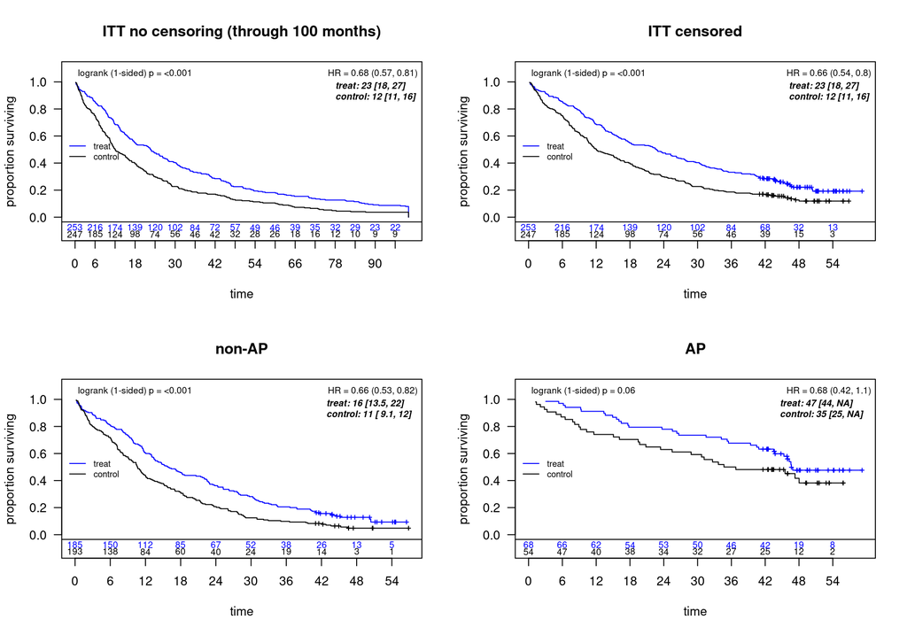

```r
# ITT
dfc <- df_counting(
  df = df_example,
  by.risk = 6,
  tte.name = "y_sim",
  event.name = "event_sim",
  treat.name = "treat_sim"
)

# No censoring
# Except by max_follow

df_example$t_true <- pmin(df_example$t_true, 100)

df_example$event_mod <- ifelse(df_example$t_true <= 100,1,0)

dfideal <- df_counting(
  df = df_example,
  by.risk = 6,
  tte.name = "t_true",
  event.name = "event_mod",
  treat.name = "treat_sim"
)


df_nonAP <- subset(df_example, z_AP == 0)
df_AP <- subset(df_example, z_AP == 1)


# non-AP
dfc0 <- df_counting(
  df = df_nonAP,
  by.risk = 6,
  tte.name = "y_sim",
  event.name = "event_sim",
  treat.name = "treat_sim"
)

# AP
dfc1 <- df_counting(
  df = df_AP,
  by.risk = 6,
  tte.name = "y_sim",
  event.name = "event_sim",
  treat.name = "treat_sim"
)


par(mfrow=c(2,2))

plot_weighted_km(dfideal, conf.int = FALSE, show.logrank = TRUE, ymax = 1.1, xmed.fraction = 0.75, ymed.offset = 0.15)
title("ITT no censoring (through 100 months)")

plot_weighted_km(dfc, conf.int = FALSE, show.logrank = TRUE, ymax = 1.1, xmed.fraction = 0.75, ymed.offset = 0.15)
title("ITT censored")

plot_weighted_km(dfc0, conf.int = FALSE, show.logrank = TRUE, ymax = 1.1, xmed.fraction = 0.725, ymed.offset = 0.15)
title("non-AP")

plot_weighted_km(dfc1, conf.int = FALSE, show.logrank = TRUE, ymax = 1.1, xmed.fraction = 0.725, ymed.offset = 0.15)
title("AP")
```

```r
confounders.name <- c("z_age","z_bm","z_male","ecog","z_histology","z_prior_treat","strat")


dfa <- as.data.frame(df_nonAP)

# Setup parallel processing
library(doFuture)
library(doRNG)

registerDoFuture()
registerDoRNG()

system.time({fs <- forestsearch(dfa,  confounders.name=confounders.name,
                                outcome.name = "y_sim", treat.name = "treat_sim", event.name = "event_sim", id.name = "id",
                                potentialOutcome.name = "loghr_po",
                                df.test = as.data.frame(df_AP),
                                flag_harm.name = NULL,
                                hr.threshold = 0.9, hr.consistency = 0.80, pconsistency.threshold = 0.80,
                                sg_focus = "minSG", max_subgroups_search = 30,
                                showten_subgroups = TRUE, details=TRUE,
                                conf_force = c("z_age <= 65", "z_bm <= 0", "z_bm <= 1", "z_bm <= 2","z_bm <= 5"),
                                cut_type = "default", use_grf = TRUE, plot.grf = TRUE, use_lasso = TRUE,
                                maxk = 1, n.min = 60, d0.min = 12, d1.min = 12,
                                plot.sg = TRUE, by.risk = 6,
                                parallel_args = list(plan="callr", workers = 100, show_message = TRUE)
)
})
```

```
GRF stage for cut selection with dmin,tau= 12 0.6
tau, maxdepth = 27.88386 2
   leaf.node control.mean control.size control.se depth
2          3        -3.67       377.00       0.98     1
21         5        -4.54       108.00       1.88     2
4          7        -6.09       194.00       1.30     2
GRF subgroup NOT found
NO GRF cuts meeting delta(RMST): dmin.grf= 12
# of continuous/categorical characteristics 2 5
Continuous characteristics: z_age z_bm
Categorical characteristics: z_male ecog z_histology z_prior_treat strat
## Prior to lasso: z_age z_bm
#### Lasso selection results
7 x 1 sparse Matrix of class "dgCMatrix"
                     s0
z_age         .
z_bm          .
z_male        .
ecog          .
z_histology   .
z_prior_treat 0.1304601
strat         .
Cox-LASSO selected: z_prior_treat
Cox-LASSO not selected: z_age z_bm z_male ecog z_histology strat
### End Lasso selection
## After lasso:
Default cuts included from Lasso:
Categorical after Lasso: z_prior_treat

===== CONSOLIDATED CUT EVALUATION (IMPROVED) =====
Evaluating 6 cut expressions once and caching...
Cut evaluation summary:
  Total cuts:  6
  Valid cuts:  6
  Errors:  0
✓ All 6 factors validated as 0/1
===== END CONSOLIDATED CUT EVALUATION =====

# of candidate subgroup factors= 6
[1] "z_age <= 65"   "z_bm <= 0"     "z_bm <= 1"     "z_bm <= 2"
[5] "z_bm <= 5"     "z_prior_treat"
Number of factors evaluated= 6
Confounders per grf screening q1 q6 q5 q4 q3 q2
        Factors Labels VI(grf)
1   z_age <= 65     q1  0.2970
6 z_prior_treat     q6  0.2092
5     z_bm <= 5     q5  0.1951
4     z_bm <= 2     q4  0.1799
3     z_bm <= 1     q3  0.1187
2     z_bm <= 0     q2  0.0000
Number of possible configurations (<= maxk): maxk = 1 , # combinations = 12
Events criteria: control >= 12 , treatment >= 12
Subgroup search completed in 0 minutes
NO subgroup candidates found
```

```
   user  system elapsed
  1.513   0.273   0.325
```

```r
plan("sequential")
```

# 5 Appendix

## 5.1 Biomarker effects with spline model

We now outline how potential outcomes are simulated according to parameters fit to the case-study dataset but with parameters specified to induce biomarker effects. That is, causal treatment effects (on log(hazard-ratio) scale) that follow a spline model according to patterns where biomarker effects increase with biomarker levels; Including various degrees of limited treatment effects for low biomarker levels.

We first consider a Weibull model with treatment and a single biomarker covariate $Z$ where we write the linear predictor of the Cox model $L'\beta$ (say) as

$$\begin{equation}
\tag{5}
L'\beta := \beta_{1}\hbox{Treat} + \beta_{2}\hbox{Z} + \beta_{3}\hbox{Z}\hbox{Treat} + \beta_{4}(\hbox{Z}-k)I(\hbox{Z}>k) + \beta_{5}(\hbox{Z}-k)I(\hbox{Z}>k)\hbox{Treat}.
\end{equation}$$

Following the potential-outcome approach let $l_{x,z}$ denote subject’s hazard-function “had they followed treatment regimen $Treat=x$ while having biomarker level $Z=z$”. That is, for subject with biomarker level $Z=z$ we can simulate their survival outcomes under both treatment ($x=1$) and control ($x=0$) conditions. Let $\beta^{0} = (\beta_{1}^{0},\ldots,\beta_{5}^{0})'$ denote the true coefficients and denote the hazard function as

$$\lambda_{x,z}(t) = \lambda_{0}(t)\exp(l_{x,z}), \quad \hbox{say}.$$

Writing

$$\begin{equation}
l_{x,z} = \beta^{0}_{1}x + \beta^{0}_{2}z + \beta^{0}_{3}zx + \beta^{0}_{4}(z-k)I(z>k) +
\beta^{0}_{5}(z-k)I(z>k)x,
\end{equation}$$
the log of the hazard ratio for biomarker level $z$ under treatment ($x=1$) relative to control ($x=0$) is given by

$$\begin{equation}
\tag{6}
\psi^{0}(z) := \log(\lambda_{1,z}(t)/\lambda_{0,z}(t)) = \beta^{0}_{1} + \beta^{0}_{3}z + \beta^{0}_{5}(z-k)I(z>k).
\end{equation}$$

## 5.2 Causal log-hazard-ratio

The log(hazard-ratio) for biomarker level $z$ is a linear function of $z$ with a change-point (in slope) at $z=k$ given by

$$\begin{eqnarray*}
\psi^{0}(z) &=& \beta^{0}_{1} + \beta^{0}_{3}z, \quad \hbox{for} \ z \leq k, \cr
&=& \beta^{0}_{1} + \beta^{0}_{3}z + \beta^{0}_{5}(z-k), \quad \hbox{for} \ z > k.
\end{eqnarray*}$$

Log hazard-ratio parameters $(\beta^{0}_{1},\beta^{0}_{3},\beta^{0}_{5})$ can be chosen to generate “treatment effect patterns” by specifying $\psi^{0}(z)$ values at $z=0$, $z=k$, and $z=\zeta$ for $\zeta > k$. For specified $\psi^{0}(0)$, $\psi^{0}(k)$, and $\psi^{0}(\zeta)$ we have

$$\begin{eqnarray}
\beta^{0}_{1} &=& \psi^{0}(0), \cr
\beta^{0}_{3} &=& {(\psi^{0}(k) - \beta^{0}_{1}) \over k}, \cr
\beta^{0}_{5} &=& {(\psi^{0}(\zeta) - \beta^{0}_{1} - \beta^{0}_{3}\zeta) \over (\zeta -k)}.
\end{eqnarray}$$

The function *get_dgm_stratified* generates $\psi^{0}(z)$ according to desired “biomarker treatment effect patterns” as follows.

- Let $X$ and $Z$ denote the treatment and biomarker variables in the case-study dataset and for specified $k$, form the covariates $L:=(X,Z,ZX,(Z-k)I(Z>k),(Z-k)I(Z>k)X))$;
- Fit the Weibull model (recall on AFT scale) to get $\log(\hat\theta)$, $\hat\tau=1/\hat{\nu}$, and $\hat\gamma$ corresponding to $L$;
- $\hat\gamma$ is in terms of the AFT parameterization given by model (3)
- Next transform to the Weibull (Cox) log hazard-ratio parameterization (4): $\hat\beta = -\hat\gamma/\hat\tau$
- Set “true” parameters $\theta^{0}=\hat\theta$, and $\tau^{0}=\hat\tau$
- Initialize the “true” parameter $\beta^{0} = \hat\beta$ and re-define parameters 1, 3, and 5 in order to satisfy specified $\psi^{0}(0)$, $\psi^{0}(k)$, and $\psi^{0}(\zeta)$: $\beta^{0}[1] = \psi^{0}(0)$, $\beta^{0}[3] = (\psi^{0}(k) - \beta^{0}[1])/k$, and $\beta^{0}[5] = (\psi^{0}(\zeta) - \beta^{0}[1] - \beta^{0}[3]\zeta)/(\zeta -k)$;
- Form corresponding $\gamma^{0}= -\beta^{0}\tau^{0}$
- For simulations we use the AFT parameterization (3) to generate $\log(T)$ outcomes according to $\log(T) = \log(\theta^{0}) + L'\gamma^{0} + \tau^{0}\epsilon$ where recall $\epsilon$ has the ``extreme value’’ distribution.

## 5.4 Including prognostic factors $W$

We extend the model to include a baseline prognostic factor $W$ within $L$ (effect parameter $\beta^{0}_{w}$) where

$$\begin{equation}
l_{x,z,w} = \beta^{0}_{1}x + \beta^{0}_{2}z + \beta^{0}_{3}zx + \beta^{0}_{4}(z-k)I(z>k) +
\beta^{0}_{5}(z-k)I(z>k)x + \beta^{0}_{w}w.
\end{equation}$$

Note that defining $m(1,z,w)$ [$m(0,z,w)$)] as the conditional expected value of $\log(T)$ with treatment set to experimental [control] given biomarker level $Z=z$ and $W=w$

$$\psi^{0}(z,w) = \{m(0,z,w)-m(1,z,w)\}/\tau$$
which corresponds to the difference in the (true) means of the potential outcomes under experimental and control conditions ($\log(T[0,z,w]$ versus $\log(T[1,z,w]$, say)

# 6 Specifying biomarker treatment effects

## 6.1 Average hazard ratios (AHRs)

We define the *biomarker average hazard ratio (AHR)* as the expected value of $\psi^{0}(\cdot)$ across “increasing biomarker” sub-populations. For example, $\hbox{AHR}(2^{+})$ represents the AHR for subjects with biomarker values $\geq 2$ via

$$\begin{equation}
\tag{6}
\hbox{AHR}(z^{+}):= \exp\left\{E_{Z \geq z} \psi^{0}(Z) \right\};
\end{equation}$$

With the opposite direction – across “decreasing biomarker” sub-populations

$$\begin{equation}
\tag{7}
\hbox{AHR}(z^{-}):= \exp\left\{E_{Z \leq z} \psi^{0}(Z) \right\}.
\end{equation}$$

Here the expectations are over the distribution of $Z$, however if there is a prognostic factor $W$ then the expectations are over $(Z,W)$. In our calculations we calculate empirical averages.

## 6.2 Controlled direct-effect (CDE) versions (Aalen, Cook, and Røysland (2015))

Averaging across hazard ratios: Define the hazard (omitting baseline hazard) $\theta^{x}(z,w) = \exp(l(x,z,w))$ setting treatment to $X=x$ given $Z=z$ and $W=w$. Aalen et al. (Aalen, Cook, and Røysland (2015)) define the controlled direct-effect (CDE) as the ratio of the expected hazards. Here we consider the above cumulative versions (omitting possible dependence on $W$). Let $\bar\theta^{x}(z+) = E_{Z \geq z}\theta^{x}(Z)$ for $x=0,1$, and define

$$\hbox{CDE}(z^{+}):= \bar\theta^{1}(z+)/\bar\theta^{0}(z+), \quad \hbox{and} \quad \hbox{CDE}(z^{-}):= \bar\theta^{1}(z-)/\bar\theta^{0}(z-)$$

## References

Aalen, O. O., R. J. Cook, and K. Røysland. 2015. “Does Cox Analysis of a Randomized Survival Study Yield a Causal Treatment Effect?” *Lifetime Data Analysis*, 579–93.

León, Larry F., Thomas Jemielita, Zifang Guo, Rachel Marceau West, and Keaven M. Anderson. 2024. “Exploratory Subgroup Identification in the Heterogeneous Cox Model: A Relatively Simple Procedure.” *Statistics in Medicine* 43 (20): 3921–42. https://doi.org/https://doi.org/10.1002/sim.10163.